# Methods of Distributional Semantics in R

## Case Study: The Distributional Semantics of Shakespeare’s Plays

## Part 2: Entity Recognition with {openNLP}

### BelgradeR Meetup :: Data Science Serbia, Startit Center

11/30/2016, Belgrade, Serbia, Startit Center, Savska 5

Organized by: Data Science Serbia and [Startit](http://en.startit.rs)

Notebook: 01/01/2017

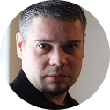

#### [Goran S. Milovanović](http://www.exactness.net), PhD

#### Data Science Mentor at [Springboard](https://www.springboard.com/workshops/data-science), [Data Science Serbia](http://www.datascience.rs)

Following my *Methods of Distributional Semantics in* BelgradeR Meetup with Data Science Serbia, organized in [Startit Center](http://en.startit.rs), Belgrade, 11/30/2016, several people asked me for the R code used for the analysis of William Shakespeare’s plays that was presented. I have decided to continue the development of that code in order to advance the examples that I have shown then into a more or less complete and comprehensible text-mining tutorial with {tm}, {openNLP}, and {topicmodels} in R. All files in this GitHub repository are a product of that work.

The second notebook in this series - **Part 2: Entity Recognition with {openNLP}** - introduces the classes provided by the {NLP} package and functions provided by {openNLP}. The {NLP} package provides a basic working infrastructure for Natural Language Processing in R; {openNLP}, on the other hand, provides an access to a set of pre-trained ML algorithms (*MaxEnt* classifiers, namely) for tasks such as tokenization, sentence segmentation, POS tagging, entity extraction, and similar. {openNLP} is really an interface to the Apache OpenNLP tools (version 1.5.3) which is written in Java.

In this notebook we will focus on entity recognition from {openNLP} by trying to extract the names of Shakespeare’s characters from its plays. In order to be able to run the entity recognition procedures from {openNLP}, we will first have to learn about *sentence segmentation* and *word tokenization*. In order to run the whole exercise that we present here, you will need to install the language specific openNLP *models*. I am providing instructions on these installations along the way.

### Part 1: The {tm} structures for text-mining in R

The fact is, you don’t really need to load all these packages in order to work with the notebook. I’m simply copying the whole *Load packages* code chunk from one notebook to another in this repository; it comprises all the packages used in the text-mining of Shakespeare’s plays. For this Part (2) of the exercise, you need to load `tm`, `dplyr`, `ggplot2`, `stringr`, `NLP`, and `openNLP` only; a call to `library(openNLP)` will automatically import `NLP` as a dependency.

**1.1 Clear all + Load packages**

```r
### --- clear all
rm(list=ls())

### ----------------------------------------------------------------------
### --- libraries

# - helpers
library(dplyr)
library(tidyr)

# - text-mining: pre-processing + stemmer, tokenizer, sentiment
library(tm)
library(tm.plugin.sentiment)
library(XML)
library(tau)
library(stringr)

# - SnowballC for Porter's stemmer
library(SnowballC)

# - Support + JVM Options
library(rJava)
numCores <- 2; # for multicore platforms
options(mc.cores=numCores)
.jinit(classpath="myClasses.jar", parameters="-Xmx512m")
library(RWeka) # load RWeka for tokenizers only after setting Options

# - topic models via Latent Dirichlet Allocation
library(topicmodels)

# - entitity recognition via Apache OpenNLP
library(openNLP)

# - graphics
library(ggplot2)
library(ggrepel)
library(igraph)
library(wordcloud)

# - analytics
library(Hmisc)
library(smacof)
library(ape)

# - parallelism
library(snowfall)
```

**1.2 Load Shakespear’s Plays: a {tm} corpus stored in Part 1.**

Let’s load `corpus` back into our environment:

```r
### ----------------------------------------------------------------------
### --- Load Shakespear's Plays

# - Load Shakespeare's Plays as a {tm} Corpus
outDir <- paste0(getwd(),"/FullCorpus")
setwd(outDir)
corpus <- readRDS('ShakespeareAnnotated.Rds')

# - Document-level Metadata in corpus:
corpus[[1]]$meta
```

```
##   author       : William Shakespeare
##   datetimestamp: 2017-01-02 10:49:09
##   description  : Comedy
##   heading      : character(0)
##   id           : All's Well That Ends Well
##   language     : en
##   origin       : http://shakespeare.mit.edu/
##   yearWritten  : 1602
##   code         : AWW
##   characters   : Parolles, Helena, Bertram, Lafeu, Countess, King of France, Clown, Second Lord, First Lord, Diana, First Soldier, Widow, Gentleman, First Gentleman, Steward, Duke of Florence, Mariana, Second Gentleman, Both, All, Second Soldier, Page, Fourth Lord, Servant
```

Store all dramatis personae into `WScharacters`:

```r
WScharacters <- meta(corpus, tag = "characters")
head(WScharacters,2)
```

```
## $`All's Well That Ends Well`
## [1] "Parolles, Helena, Bertram, Lafeu, Countess, King of France, Clown, Second Lord, First Lord, Diana, First Soldier, Widow, Gentleman, First Gentleman, Steward, Duke of Florence, Mariana, Second Gentleman, Both, All, Second Soldier, Page, Fourth Lord, Servant"
##
## $`A Midsummer Night's Dream`
## [1] "Bottom, Lysander, Hermia, Theseus, Demetrius, Quince, Helena, Puck, Oberon, Titania, Flute, Hippolyta, Snout, Starveling, Egeus, Philostrate, Mustardseed, Peaseblossom, Fairy, Cobweb, Snug, All, Moth"
```

We will focus on **Macbeth** to demonstrate the transformations that we will be later applying over the whole corpus:

```r
# - Macbeth:
corpus[[19]]$meta$id
```

```
## [1] "Macbeth"
```

```r
macbeth <- corpus[[19]]$content
class(macbeth)
```

```
## [1] "character"
```

**1.3 Some pre-processing**

In order to demonstrate named entitiry recognition from {opeNLP} in R, we will first apply a set of gentle transformations over `macbeth` - that is simply a `character` now - to improve upon its readibility, to put it that way. I will explain this later:

```r
# - a small correction: CHARACTERS to Names:
# - CHARACTERS to Titles w. {string}:
candidateCharacters1 <- unique(str_extract_all(macbeth, "[[:upper:]]{2,}\\s[[:upper:]]{2,}")[[1]])
candidateCharacters2 <- unique(str_extract_all(macbeth, "[[:upper:]]{2,}")[[1]])
candidateCharacters1
```

```
##  [1] "SCENE II"        "SCENE III"       "SCENE IV"
##  [4] "LADY MACBETH"    "SCENE VI"        "SCENE VII"
##  [7] "MACBETH MACBETH" "ACT II"          "MACBETH LENNOX"
## [10] "ACT III"         "BANQUO BANQUO"   "GHOST OF"
## [13] "ACT IV"          "LADY MACDUFF"    "ROSS LADY"
## [16] "MACDUFF MALCOLM" "YOUNG SIWARD"    "SCENE VIII"
```

```r
candidateCharacters2
```

```
##  [1] "ACT"       "SCENE"     "ALL"       "II"        "DUNCAN"
##  [6] "MALCOLM"   "DONALBAIN" "LENNOX"    "ROSS"      "III"
## [11] "MACBETH"   "BANQUO"    "ANGUS"     "IV"        "LADY"
## [16] "VI"        "MACDUFF"   "VII"       "FLEANCE"   "ATTENDANT"
## [21] "GHOST"     "OF"        "HECATE"    "MENTEITH"  "CAITHNESS"
## [26] "SEYTON"    "SIWARD"    "YOUNG"     "VIII"
```

The previous two calls use `regex` and `str_extract_all` from {stringr} to extract all word or phrase of length two instances from `macbeth` typed in CAPITAL letters. The reason why I need this is the following: in the MIT edition of Shakespeare’s plays that I am using here, character names always appear in capital letters *before giving a speech*. I want to take care of that by turning them into a graphemically more typical form: ‘LADY MACBETH’ to ‘Lady Macbeth’, for example.

Now, as you can see from the output, there are things there that we don’t wish to consider as candidates for character name recognition from plays:

```r
candidateCharacters <- c(candidateCharacters1, candidateCharacters2)
# - clean up w. regex:
candidateCharacters <- candidateCharacters[-which(grepl("^ACT|\\bACT\\b", candidateCharacters))]
candidateCharacters <- candidateCharacters[-which(grepl("^SCENE|\\bSCENE\\b", candidateCharacters))]
# - Remove Roman numerals I - X w. regex:
candidateCharacters <- candidateCharacters[-which(grepl("^I{1,3}$|^VI{1,3}$|^IV$|^V$|^IX$|^X$", candidateCharacters))]
candidateCharacters
```

```
##  [1] "LADY MACBETH"    "MACBETH MACBETH" "MACBETH LENNOX"
##  [4] "BANQUO BANQUO"   "GHOST OF"        "LADY MACDUFF"
##  [7] "ROSS LADY"       "MACDUFF MALCOLM" "YOUNG SIWARD"
## [10] "ALL"             "DUNCAN"          "MALCOLM"
## [13] "DONALBAIN"       "LENNOX"          "ROSS"
## [16] "MACBETH"         "BANQUO"          "ANGUS"
## [19] "LADY"            "MACDUFF"         "FLEANCE"
## [22] "ATTENDANT"       "GHOST"           "OF"
## [25] "HECATE"          "MENTEITH"        "CAITHNESS"
## [28] "SEYTON"          "SIWARD"          "YOUNG"
```

Ok. This is better. Now we will use the {stringr} function `str_to_title()` to transform these candidate character names from CAPITAL letters into Title (i.e., “MACBETH” to “Macbeth”):

```r
# - implement:
for (i in 1:length(candidateCharacters)) {
  macbeth <- str_replace_all(macbeth, candidateCharacters[i], str_to_title(candidateCharacters[i]))
}
```

**1.4 {NLP} and {openNLP} word and sentence annotations**

Time to introduce {NLP} and {openNLP}. In order to use the functions offered by these two packages, we first need to transform whatever is a `character` class (for example, the `$content` of a `PlainTextDocument` from our {tm} corpora) into an object of a `String` class which is used by {NLP} and {openNLP}:

```r
# - String class for {NLP} and {openNLP}
macbeth <- as.String(macbeth)
class(macbeth)
```

```
## [1] "String"
```

The `String` class enables us to subset the content of its instantiated objects by referring to the starting and ending character positions:

```r
macbeth[10,20] # subsetting string objects in {NLP}
```

```
## edy of Macb
```

```r
macbeth[102,178]
```

```
## First Witch When shall we three meet again In thunder, lightning, or in rain?
```

The first two things that we want to do is to ask {openNLP} to segment `macbeth` into sentences and to tokenize it into words. These are very, very standard operations in text-mining and NLP, only sometimes you will have to go for tokenizing your texts into words *and* phrases of different length, and not words only. Here we will go for the simpler case. In order to perform text segmentation and tokenization, we first need to prepare some `Annotator`s from {openNLP}:

```r
# - Word and Sentence annotators:
wordAnnotator <- Maxent_Word_Token_Annotator(language = "en") # {openNLP}
wordAnnotator
```

```
## An annotator inheriting from classes
##   Simple_Word_Token_Annotator Annotator
## with description
##   Computes word token annotations using the Apache OpenNLP Maxent
##   tokenizer employing the default model for language 'en'.
```

```r
sentenceAnnotator <- Maxent_Sent_Token_Annotator(language = "en") # {openNLP}
sentenceAnnotator
```

```
## An annotator inheriting from classes
##   Simple_Sent_Token_Annotator Annotator
## with description
##   Computes sentence annotations using the Apache OpenNLP Maxent
##   sentence detector employing the default model for language 'en'.
```

These two functions are now our interfaces towards the Java functions that will actually perform sentence segmentation and word tokenization over `macbeth` from our R environment. To perform the annotation of `macbeth` with these two annotators, call `annotate` **from NLP** (N.B. you have loaded `ggplot2` which also uses `annotate`; many people ask about error feedbacks from `annotate()` on Stackoverflow without actually realizing that they need to overide `ggplot2`’s `(annotate()` by calling `NLP::annotate()`).

This might take some time:

```r
# - annotate Macbeth: N.B. use NLP::annotate to override ggplot2's annotate()!
annotatedMacbeth <- NLP::annotate(macbeth,
                                  list(sentenceAnnotator, wordAnnotator))
class(annotatedMacbeth)
```

```
## [1] "Annotation" "Span"
```

Let’s learn about the properties of the `Annotation` class:

```r
length(annotatedMacbeth)
```

```
## [1] 23274
```

```r
annotatedMacbeth[[1]]
```

```
##  id type     start end features
##   1 sentence     2  40 constituents=<<integer,8>>
```

```r
annotatedMacbeth[[2]]
```

```
##  id type     start end features
##   2 sentence    42  56 constituents=<<integer,4>>
```

```r
annotatedMacbeth[[2]]$start
```

```
## [1] 42
```

And we have already learn that we can subset `String` objects by:

```r
macbeth[annotatedMacbeth[[2]]$start, annotatedMacbeth[[2]]$end]
```

```
## A desert place.
```

which extract a full sentence from `macbeth`: `annotatedMacbeth[[2]]` has a `type` field, which in this case has a value of `sentence` whose beginning is at the position stored in `start` and which ends at the position stored in `end`. This sentences, as we can see, has 4 constituents (namely: `A`, `desert`, `place`, `.`).

```r
annotatedMacbeth[[1]]$features
```

```
## [[1]]
## [[1]]$constituents
## [1] 1196 1197 1198 1199 1200 1201 1202 1203
```

1196, 1197, 1198, 1199,… : what are these numbers..?

```r
class(annotatedMacbeth[[1]]$features)
```

```
## [1] "list"
```

```r
annotatedMacbeth[[1]]$features[[1]]$constituents
```

```
## [1] 1196 1197 1198 1199 1200 1201 1202 1203
```

The numbers are the `id` fields of the word entities that were recognized by {openNLP} following the text tokenization; if you recall, we’ve asked for sentence segmentation and word tokenization. It will be easier to explain if I first transform `annotatedMacbeth` to a data.frame:

```r
# $constituents:
annMacbeth <- as.data.frame(annotatedMacbeth)
head(annMacbeth)
```

```
##   id     type start end
## 1  1 sentence     2  40
## 2  2 sentence    42  56
## 3  3 sentence    59  80
## 4  4 sentence    82 178
## 5  5 sentence   180 251
## 6  6 sentence   253 296
##                                                                                                                 features
## 1                                                                         1196, 1197, 1198, 1199, 1200, 1201, 1202, 1203
## 2                                                                                                 1204, 1205, 1206, 1207
## 3                                                                                                 1208, 1209, 1210, 1211
## 4 1212, 1213, 1214, 1215, 1216, 1217, 1218, 1219, 1220, 1221, 1222, 1223, 1224, 1225, 1226, 1227, 1228, 1229, 1230, 1231
## 5                         1232, 1233, 1234, 1235, 1236, 1237, 1238, 1239, 1240, 1241, 1242, 1243, 1244, 1245, 1246, 1247
## 6                                                       1248, 1249, 1250, 1251, 1252, 1253, 1254, 1255, 1256, 1257, 1258
```

`annotatedMacbeth` has stored sentence annotations from `macbeth` first, and…

```r
tail(annMacbeth)
```

```
##          id type  start    end features
## 23269 23269 word 100128 100129     NULL
## 23270 23270 word 100131 100135     NULL
## 23271 23271 word 100136 100136     NULL
## 23272 23272 word 100138 100145     NULL
## 23273 23273 word 100146 100146     NULL
## 23274 23274 word 100148 100153     NULL
```

… words annotations after them. Let’s pick only word annotations from `macbeth`:

```r
annMacbeth <- annMacbeth %>%
  filter(type == "word")
annotatedMacbeth[[1]]$features[[1]]$constituents
```

```
## [1] 1196 1197 1198 1199 1200 1201 1202 1203
```

```r
length(annotatedMacbeth[[1]]$features[[1]]$constituents)
```

```
## [1] 8
```

```r
# the constituents of annotatedMacbeth[[1]]: words in a sentence
annMacbeth$id[1:8]
```

```
## [1] 1196 1197 1198 1199 1200 1201 1202 1203
```

Now when we understand the structure of the `Annotation` object, let’s use it in conjunction with the `macbeth` (which is a `String`) to produce an `AnnotatedPlainTextDocument`:

```r
# - AnnotatedPlainTextDocument
macbethAPT <- AnnotatedPlainTextDocument(macbeth, annotatedMacbeth)
class(macbethAPT)
```

```
## [1] "AnnotatedPlainTextDocument" "PlainTextDocument"
## [3] "TextDocument"
```

We have met some of these in {tm} already; and of course:

```r
is.list(macbethAPT)
```

```
## [1] TRUE
```

Let’ find out more about the properties of this object:

```r
length(macbethAPT$annotations[[1]])
```

```
## [1] 23274
```

```r
macbethAPT$annotations[[1]][[23274]]
```

```
##  id    type start  end    features
##  23274 word 100148 100153
```

```r
length(sents(macbethAPT)) # 1195
```

```
## [1] 1195
```

```r
is.list(sents(macbethAPT))
```

```
## [1] TRUE
```

The `sents()` function extracts sentences:

```r
sents(macbethAPT)[[100]]
```

```
##  [1] "Enter"    "Ross"     "and"      "Angus"    "Ross"     "The"
##  [7] "king"     "hath"     "happily"  "received" ","        "Macbeth"
## [13] ","        "The"      "news"     "of"       "thy"      "success"
## [19] ";"        "and"      "when"     "he"       "reads"    "Thy"
## [25] "personal" "venture"  "in"       "the"      "rebels"   "'"
## [31] "fight"    ","        "His"      "wonders"  "and"      "his"
## [37] "praises"  "do"       "contend"  "Which"    "should"   "be"
## [43] "thine"    "or"       "his"      ":"        "silenced" "with"
## [49] "that"     ","        "In"       "viewing"  "o"        "'er"
## [55] "the"      "rest"     "o"        "'"        "the"      "selfsame"
## [61] "day"      ","        "He"       "finds"    "thee"     "in"
## [67] "the"      "stout"    "Norweyan" "ranks"    ","        "Nothing"
## [73] "afeard"   "of"       "what"     "thyself"  "didst"    "make"
## [79] ","        "Strange"  "images"   "of"       "death"    "."
```

```r
class(sents(macbethAPT)[[1]])
```

```
## [1] "character"
```

```r
sents(macbethAPT) %>% head(5)
```

```
## [[1]]
## [1] "The"     "Tragedy" "of"      "Macbeth" "ACT"     "I"       "SCENE"
## [8] "I."
##
## [[2]]
## [1] "A"      "desert" "place"  "."
##
## [[3]]
## [1] "Thunder"   "and"       "lightning" "."
##
## [[4]]
##  [1] "Enter"     "three"     "Witches"   "First"     "Witch"
##  [6] "When"      "shall"     "we"        "three"     "meet"
## [11] "again"     "In"        "thunder"   ","         "lightning"
## [16] ","         "or"        "in"        "rain"      "?"
##
## [[5]]
##  [1] "Second"     "Witch"      "When"       "the"        "hurlyburly"
##  [6] "'s"         "done"       ","          "When"       "the"
## [11] "battle"     "'s"         "lost"       "and"        "won"
## [16] "."
```

And `words()` would be for extracting words:

```r
words(macbethAPT) %>% head(100)
```

```
##   [1] "The"        "Tragedy"    "of"         "Macbeth"    "ACT"
##   [6] "I"          "SCENE"      "I."         "A"          "desert"
##  [11] "place"      "."          "Thunder"    "and"        "lightning"
##  [16] "."          "Enter"      "three"      "Witches"    "First"
##  [21] "Witch"      "When"       "shall"      "we"         "three"
##  [26] "meet"       "again"      "In"         "thunder"    ","
##  [31] "lightning"  ","          "or"         "in"         "rain"
##  [36] "?"          "Second"     "Witch"      "When"       "the"
##  [41] "hurlyburly" "'s"         "done"       ","          "When"
##  [46] "the"        "battle"     "'s"         "lost"       "and"
##  [51] "won"        "."          "Third"      "Witch"      "That"
##  [56] "will"       "be"         "ere"        "the"        "set"
##  [61] "of"         "sun"        "."          "First"      "Witch"
##  [66] "Where"      "the"        "place"      "?"          "Second"
##  [71] "Witch"      "Upon"       "the"        "heath"      "."
##  [76] "Third"      "Witch"      "There"      "to"         "meet"
##  [81] "with"       "Macbeth"    "."          "First"      "Witch"
##  [86] "I"          "come"       ","          "Graymalkin" "!"
##  [91] "Second"     "Witch"      "Paddock"    "calls"      "."
##  [96] "Third"      "Witch"      "Anon"       "."          "All"
```

Let’s get ready to annotate the whole corpus of Shakespeare’s plays!

```r
# - clear
rm(list = c('annMacbeth', 'annotatedMacbeth', 'macbethAPT'))
```

**1.5 Entity recognition with {openNLP}**

**Note:** In order to perform entity recognition from {openNLP}, your documents must first undergo sentence and word tokenization as described.

Apache OpenNLP relies on a set of pre-trained models in entity recognition; these models are *language-specific*. We are interested in personal name recognition, and from the [list of models available in openNLP 1.5 series](http://openNLP.sourceforge.net/models-1.5/) we can find out that the available models for this task are for English, Dutch, and Spanish only. Well, that is a constraint, but a one that we will have to leave with (did you say “English” - well, didn’t Shakespeare’s use exactly that language..? - He did, but he also wrote about people like *Romeo*, *Antonio*, *Caesar*, and many more of not quite typicall English names, right…)

In order to be able to use these language-specific models, one first needs to install them. The models can be accessed from http://datacube.wu.ac.at/; the installation procedure is as follows:

```r
### --- Entity Recognition from {openNLP}
# - create an annotator:
# - list of models available in openNLP 1.5 series:
# - http://openNLP.sourceforge.net/models-1.5/
# - visit: http://datacube.wu.ac.at/
# - To install for Spanish:
install.packages("http://datacube.wu.ac.at/src/contrib/openNLPmodels.es_1.5-1.tar.gz",
                 repos = NULL,
                 type = "source")
# - To install for Dutch:
install.packages("http://datacube.wu.ac.at/src/contrib/openNLPmodels.nl_1.5-2.tar.gz",
                 repos = NULL,
                 type = "source")
```

Now we need to create new `Annotator` objects for specific languages and `kind`s of entities that we are looking for - personal names in this case:

```r
characterAnnotatorEN <- Maxent_Entity_Annotator(language = "en", kind = "person")
characterAnnotatorES <- Maxent_Entity_Annotator(language = "es", kind = "person")
characterAnnotatorNL <- Maxent_Entity_Annotator(language = "nl", kind = "person")
```

Do `?Maxent_Entity_Annotator` and find out about all different kinds of entities that {openNLP} can help recognize.

Let’s annotate the `macbeth` `String` again, this time by first running `sentenceAnnotator` and `wordAnnotator`, and then calling three `characterAnnotator`s: for English, Spanish, and Dutch - one by one:

```r
annotatedMacbeth <- NLP::annotate(macbeth,
                                  list(sentenceAnnotator,
                                       wordAnnotator,
                                       characterAnnotatorEN,
                                       characterAnnotatorES,
                                       characterAnnotatorNL))
```

Since we know how to convert an `Annotator` object to a `data.frame`, we can easily extract only entities from it:

```r
# - keep only person entity annotations:
annotatedMacbeth <- annotatedMacbeth %>%
  as.data.frame %>%
  filter(type == "entity")
# - extract Shakespeare's characters from Macbeth:
charactersMachbet <- str_sub(as.character(macbeth),
                             start = annotatedMacbeth$start,
                             end = annotatedMacbeth$end) %>%
  unique()
charactersMachbet
```

```
##   [1] "Enter Duncan"                  "Malcolm"
##   [3] "Duncan What"                   "Malcolm This"
##   [5] "Duncan"                        "O"
##   [7] "Mark"                          "Compell"
##   [9] "Ross"                          "Malcolm The"
##  [11] "Ross God"                      "Ross From Fife"
##  [13] "Ross That"                     "Ross I"
##  [15] "Angus  Ross"                   "Ross And"
##  [17] "In"                            "When"
##  [19] "Malcolm My"                    "Banquo"
##  [21] "Noble Banquo"                  "castle"
##  [23] "Macbeth O"                     "Macduff"
##  [25] "Angus"                         "Duncan Hath"
##  [27] "Porter Porter Here"            "Porter"
##  [29] "Porter Marry"                  "Dear Duff"
```

[output cut: 102 more lines]

Ooops… does this look like a like of characters from Macbeth at all? Let’s compare this with what we have already stored as this play’s characters in the `corpus`:

```r
# - compare:
charactersMachbetCorpus <- unlist(strsplit(WScharacters[[19]],
                                           split = ", ", fixed = T)[[1]])
foundCharacters <- charactersMachbetCorpus[which(charactersMachbetCorpus %in% charactersMachbet)]
foundCharacters
```

```
##  [1] "Lady Macbeth"   "Macduff"        "Malcolm"        "Ross"
##  [5] "Banquo"         "Lennox"         "First Murderer" "Doctor"
##  [9] "Duncan"         "Third Witch"    "Siward"         "Young Siward"
## [13] "Angus"          "Porter"         "Old Man"        "Lords"
## [17] "Hecate"
```

```r
# - accuracy:
acc <- round((length(foundCharacters)/length(charactersMachbetCorpus))*100,2)
acc
```

```
## [1] 42.5
```

Only about 42.5% of characters were recognized. Here’a a little to trick to improve upon this and similar results:

```r
# - let's provide a small assistance to {openNLP}...
charactersMachbet <- unique(c(charactersMachbet,
                              unique(
                                unlist(strsplit(charactersMachbet,
                                                split = " ",
                                                fixed = T)))
                              )
                            )
foundCharacters <-
  charactersMachbetCorpus[which(charactersMachbetCorpus %in% charactersMachbet)]
foundCharacters
```

```
##  [1] "Macbeth"        "Lady Macbeth"   "Macduff"        "Malcolm"
##  [5] "Ross"           "Banquo"         "Lennox"         "First Murderer"
##  [9] "Doctor"         "Duncan"         "Third Witch"    "Gentlewoman"
## [13] "Siward"         "Messenger"      "Menteith"       "Servant"
## [17] "Young Siward"   "Angus"          "Porter"         "Old Man"
## [21] "Lords"          "Sergeant"       "Lord"           "Hecate"
## [25] "Fleance"        "Soldiers"
```

We have simply split all multi-term entities into terms of length 1 and then intersected the new entries with the existing ones.

```r
# - accuracy:
acc <- round((length(foundCharacters)/length(charactersMachbetCorpus))*100,2)
acc
```

```
## [1] 65
```

The accuracy of recognition is now at **65%**, and let’s be clear about two things:

- *first*, this is **not** the way to evaluate how successfull an information extraction system is; in real-world settings, we would not have a pre-defined list of entities to compare against, neither would our approach to tokenize multi-term entities into single term entities bear any validity (in real world application over completelly unknown documents, what could justify the assumption that any personal names are enclosed in the multi-term entities suggest by an ML model?);
- *second*, the result is rather poor, even when viewed in the setting of analysis as described here.

*However*, Shakespeare’s English is not the easiest case to crack with machine learning based entity recognition: namely, the {openNLP} models were certainly not trained to recognize anything from 16th century English plays, putting aside the problem of having personal name entity recognition models for a small selection of languages only. I have used {openNLP} entitity recognition in professional settings and to process documents written in contemporary English - and its performance was far better than what we can see here.

**1.6 The whole Shakespeare undergoes {openNLP} entity recognition…**

What I will try do here is the following:

- annotate all 37 Shakespeare’s plays with {openNLP};
- perform named entity recogniton from {openNLP} over the annotated plays, hoping to extract the names of Shakespeare’s characters from the plays;
- compare the performance of the MaxEnt Apache openNLP models for personal names recognition with the already stored lists of characters in `corpus` for each play.

The following code will simply loop through the whole `corpus` and perform {openNLP} entitity recognition, recycling all steps already presented in the case of `macbeth`. This will take a while (where `'a while' == 'a coffee break wouldn't heart at this point'`):

```r
# - Annotate all plays
### ----------------------------------------------------------------------
recognized <- character()
accuracy <- numeric()
# - a directory where annotated plays will be saved as .Rds files
setwd(paste0(getwd(),"/FullCorpus/openNLPAnnotations"))
for (i in 1:length(corpus)) {
  print(paste0("Processing play ", i, ". out of 37..."))
  play <- corpus[[i]]$content
  # - CHARACTERS to Titles w. {string}:
  candidateCharacters1 <-
    unique(str_extract_all(play, "[[:upper:]]{2,}\\s[[:upper:]]{2,}")[[1]])
  candidateCharacters2 <-
    unique(str_extract_all(play, "[[:upper:]]{2,}")[[1]])
  candidateCharacters <-
    c(candidateCharacters1, candidateCharacters2)
  # - clean up w. regex:
  candidateCharacters <-
    candidateCharacters[-which(grepl("^ACT|\\bACT\\b", candidateCharacters))]
  candidateCharacters <-
    candidateCharacters[-which(grepl("^SCENE|\\bSCENE\\b", candidateCharacters))]
  # - Remove Roman numerals I - X w. regex:
  candidateCharacters <-
    candidateCharacters[-which(grepl("^I{1,3}$|^VI{1,3}$|^IV$|^V$|^IX$|^X$", candidateCharacters))]
  # - implement:
  for (j in 1:length(candidateCharacters)) {
    play <-
      str_replace_all(play, candidateCharacters[j], str_to_title(candidateCharacters[j]))
  }

  # - annotate w. {openNLP}
  play <- as.String(play)
  annotatedPlay <- NLP::annotate(play,
                                 list(sentenceAnnotator,
                                      wordAnnotator,
                                      characterAnnotatorEN,
                                      characterAnnotatorES,
                                      characterAnnotatorNL))
  saveRDS(annotatedPlay, file = paste0(corpus[[i]]$meta$id,
                                       "_Annotated.Rds"))

  annotatedPlay <- annotatedPlay %>%
    as.data.frame() %>%
    filter(type == "entity")

  foundCharacters <- str_sub(as.character(play),
                             start = annotatedPlay$start,
                             end = annotatedPlay$end) %>%
    unique()

  # - a small hint to help {openNLP}:
  foundCharacters <- unique(c(foundCharacters,
                              unique(
                                unlist(strsplit(foundCharacters,
                                                split = " ",
                                                fixed = T)))
                              )
                            )

  corpusCharacters <- unlist(strsplit(corpus[[i]]$meta$characters,
                                      split = ", ",
                                      fixed = T))

  recognized[i] <-
    paste(corpusCharacters[which(corpusCharacters %in% foundCharacters)],
                         collapse = ", ")

  accuracy[i] <-
    length(corpusCharacters[which(corpusCharacters %in% foundCharacters)])/length(corpusCharacters)

  rm(list = c('play','annotatedPlay','foundCharacters','corpusCharacters'))

}
```

Extract only the data that are necessary to inspect the performance of {openNLP}:

```r
charRecognition <- data.frame(play = as.character(meta(corpus, tag = "id")),
                              recognized = recognized,
                              accuracy = accuracy,
                              stringsAsFactors = F)
charRecognition$type = as.character(meta(corpus, tag = "description"))
charRecognition$numCharsFound <- sapply(charRecognition$recognized, function(x) {
  length(strsplit(x, split = ", ", fixed = T)[[1]])
})
charRecognition$numCharsCorpus <- sapply(meta(corpus, tag = "characters"), function(x) {
  length(strsplit(x, split = ", ", fixed = T)[[1]])
})
write.csv(charRecognition, file = "charRecognition.csv")
```

**1.7 Evaluation: how well does {openNLP} perform against Shakespeare’s plays?**

Now, let’s see:

```r
# - Results
### ----------------------------------------------------------------------
rm(list=ls())
library(dplyr)
library(ggplot2)
charRecognition <- read.csv("charRecognition.csv",
                            header = T,
                            row.names = 1,
                            stringsAsFactors = F)
head(charRecognition)
```

```
##                        play
## 1 All's Well That Ends Well
## 2 A Midsummer Night's Dream
## 3      Antony and Cleopatra
## 4            As You Like It
## 5                Coriolanus
## 6                 Cymbeline
##                                                                                                                                                                                                                                                                                                          …
## 1                                                                                                                                                                                                        Parolles, Helena, Bertram, Lafeu, Clown, Second Lord, First Lord, Diana, First Soldier, Widow, G…
## 2                                                                                                                                                Bottom, Lysander, Hermia, Theseus, Demetrius, Quince, Helena, Puck, Oberon, Titania, Flute, Hippolyta, Snout, Starveling, Egeus, Philostrate, Mustardsee…
## 3 Antony, Cleopatra, Octavius, Charmian, Messenger, Pompey, Menas, Lepidus, Agrippa, Eros, Dolabella, Iras, Mecaenas, Alexas, Soothsayer, Soldier, Octavia, Scarus, Thyreus, Second Soldier, Third Soldier, Proculeius, Canidius, All, Diomedes, Mardian, Ventidius, Silius, Attendant, Egyptian, Guard, …
## 4                                                                                                                                                                                           Rosalind, Orlando, Celia, Touchstone, Oliver, Duke, Corin, Silvius, Phebe, Frederick, Audrey, William, Adam, …
## 5                                                       Coriolanus, Sicinius Velutus, Junius Brutus, Cominius, Volumnia, Tullus Aufidius, Virgilia, Titus Lartius, Third Servingman, First Servingman, Second Servingman, Citizens, Valeria, Messenger, Second Senator, Aedile, Roman, First Soldier, Lie…
## 6                                                                                                                                         Imogen, Cymbeline, Posthumus Leonatus, Iachimo, Cloten, Guiderius, Pisanio, Belarius, Arviragus, Queen, Caius Lucius, Second Lord, Philario, Cornelius, Lady, S…
##    accuracy    type numCharsFound numCharsCorpus
## 1 0.5833333  Comedy            14             24
## 2 0.9130435  Comedy            21             23
## 3 0.6296296 Tragedy            34             54
## 4 0.6923077  Comedy            18             26
## 5 0.3859649 Tragedy            22             57
## 6 0.5000000  Comedy            19             38
```

```r
summary(charRecognition$accuracy)
```

```
##    Min. 1st Qu.  Median    Mean 3rd Qu.    Max.
##  0.2759  0.5200  0.5833  0.6043  0.6923  0.9310
```

```r
charRecognition$recognized[26] # Romeo and Juliet
```

```
## [1] "Romeo, Juliet, Nurse, Benvolio, Mercutio, Friar Laurence, Capulet, Lady Capulet, Paris, Sampson, Tybalt, Gregory, Peter, Balthasar, Montague, Servant, Abraham, Friar John, Page, Second Capulet, Lady Montague"
```

```r
charRecognition$recognized[19] # Macbeth
```

```
## [1] "Macbeth, Lady Macbeth, Macduff, Malcolm, Ross, Banquo, Lennox, First Murderer, Doctor, Duncan, Third Witch, Gentlewoman, Siward, Messenger, Menteith, Servant, Young Siward, Angus, Porter, Old Man, Lords, Sergeant, Lord, Hecate, Fleance, Soldiers"
```

```r
charRecognition$recognized[15] # Julius Caesar
```

```
## [1] "Antony, Brutus, Cassius, Octavius, Caesar, Casca, Lucius, Messala, Fourth Citizen, Portia, Decius Brutus, Cinna, Lucilius, Soothsayer, All, Clitus, Calpurnia, Pindarus, Ligarius, Metellus Cimber, Trebonius, Artemidorus, Cicero, Dardanius, Volumnius, Claudius, Popilius"
```

And that would be it. Plot the accuracy distribution (reminder: “accuracy” is, in the context of this analysis, defined as a proportion of correct recognitions merely):

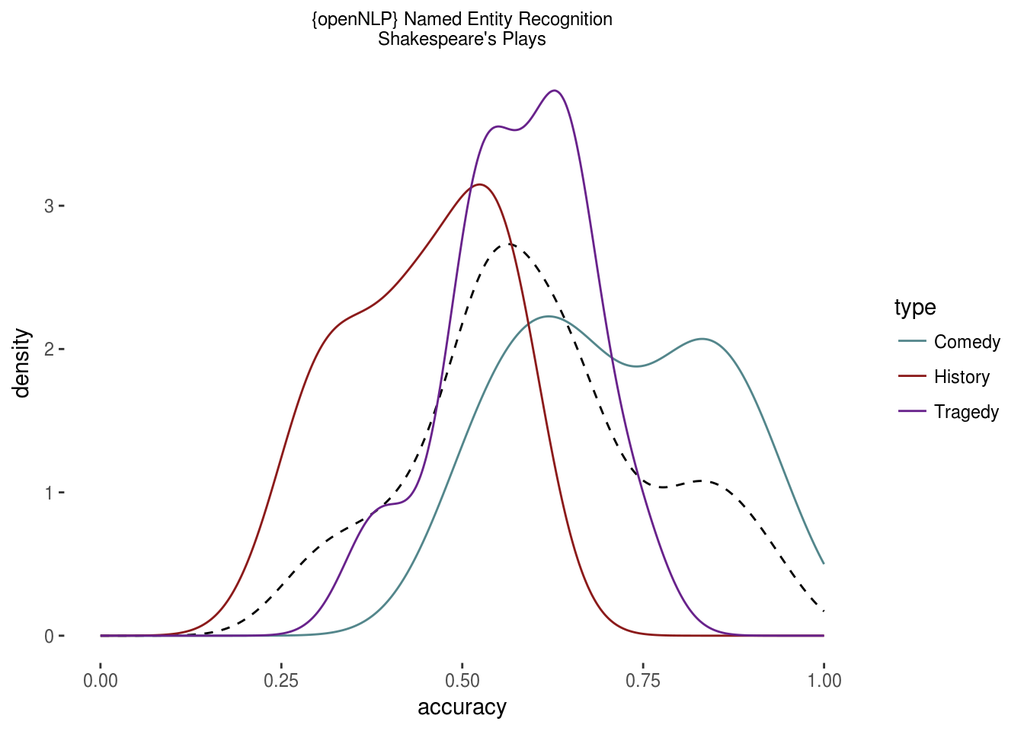

```r
# - accuracy density plot
ggplot(data = charRecognition) +
  geom_line(aes(accuracy), stat="density", color = "black", linetype = 2) +
  geom_line(aes(accuracy, color = type), stat="density") +
  scale_colour_manual(values = c("cadetblue4","firebrick4", "darkorchid4")) +
  theme_classic() +
  ggtitle("{openNLP} Named Entity Recognition\nShakespeare's Plays") +
  theme(axis.line.y = element_blank()) +
  theme(axis.line.x = element_blank()) +
  theme(plot.title = element_text(size = 9, hjust = .5)) +
  xlim(0,1)
```

The dashed black line represents the overall accuracy density. Next question: are there any significant differences in successful recognitions from Shakespeare’s comedies, tragedies, and historical plays?

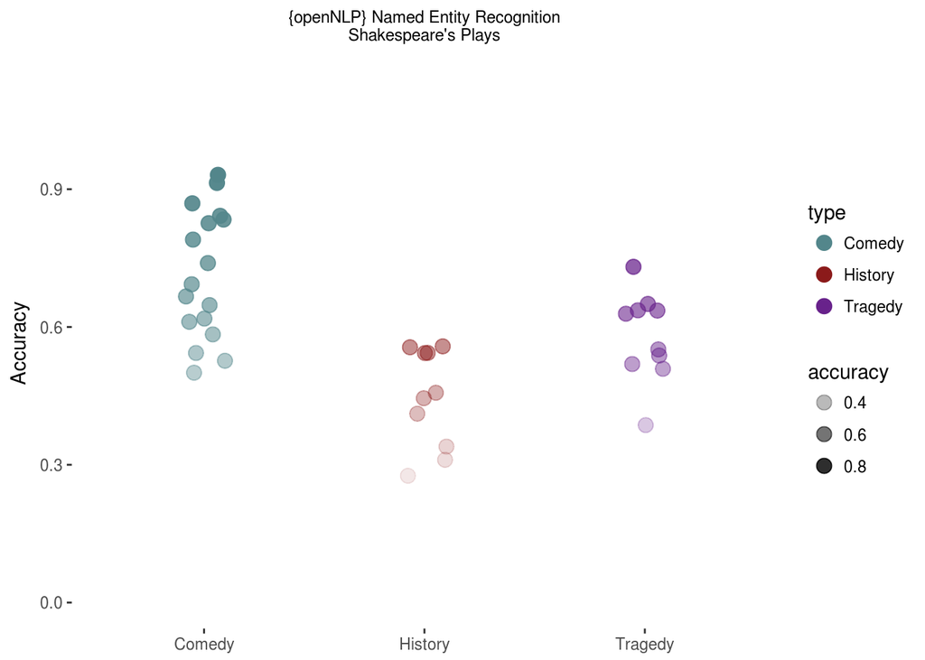

```r
# - plot accuracy by type
ggplot(data = charRecognition,
       aes(x = type, y = accuracy, color = type)) +
  scale_colour_manual(values = c("cadetblue4","firebrick4", "darkorchid4")) +
  geom_jitter(aes(alpha = accuracy), size = 3.5, width = .1) +
  ylim(0, max(charRecognition$accuracy)+.2) + xlab(NULL) + ylab("Accuracy") +
  ggtitle("{openNLP} Named Entity Recognition\nShakespeare's Plays") +
  theme_classic() +
  theme(axis.line.y = element_blank()) +
  theme(axis.line.x = element_blank()) +
  theme(plot.title = element_text(size = 9, hjust = .5))
```

Some descriptive statistics on accuracy:

```r
# - accuracy by type
charRecognition %>%
  group_by(type) %>%
  summarise(MeanAcc = mean(accuracy),
            StDevAcc = sd(accuracy),
            meanNumChar = mean(numCharsCorpus)) %>%
  arrange(desc(MeanAcc))
```

```
## # A tibble: 3 × 4
##      type   MeanAcc   StDevAcc meanNumChar
##     <chr>     <dbl>      <dbl>       <dbl>
## 1  Comedy 0.7136289 0.14024490    25.94118
## 2 Tragedy 0.5788007 0.09731292    39.60000
## 3 History 0.4439815 0.10711851    46.20000
```

This differences here could be due to the differences in the number of characters that take part in different types of Shakespeare’s plays:

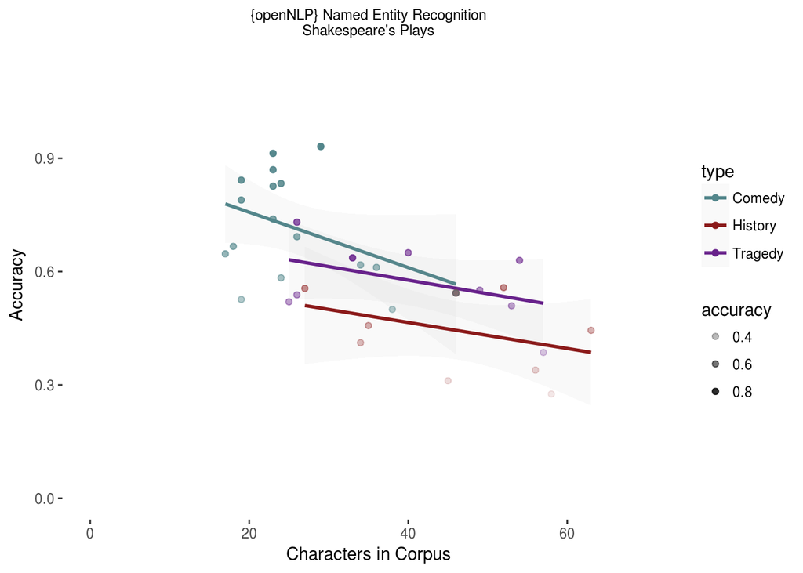

```r
# - plot accuracy by type 2
ggplot(data = charRecognition,
       aes(x = numCharsCorpus, y = accuracy, color = type)) +
  scale_colour_manual(values = c("cadetblue4","firebrick4", "darkorchid4")) +
  theme_classic() +
  geom_smooth(method = lm, alpha = .05) +
  geom_point(aes(alpha = accuracy)) +
  ylim(0, max(charRecognition$accuracy)+.2) +
  xlim(0, 70) +
  ylab("Accuracy") + xlab("Characters in Corpus") +
  ggtitle("{openNLP} Named Entity Recognition\nShakespeare's Plays") +
  theme(axis.line.y = element_blank()) +
  theme(axis.line.x = element_blank()) +
  theme(plot.title = element_text(size = 9, hjust = .5))
```

Of course it is more difficult to be successful in recognition with more characters in a play to recognize; however, is there a *significant* effect when interactions with the type of play are taken into account?

```r
playsFit1 <-
  glm(cbind(numCharsFound, numCharsCorpus-numCharsFound) ~ type + type:numCharsCorpus,
      family = binomial(logit),
      data = charRecognition)
summary(playsFit1)
```

```
##
## Call:
## glm(formula = cbind(numCharsFound, numCharsCorpus - numCharsFound) ~
##     type + type:numCharsCorpus, family = binomial(logit), data = charRecognition)
##
## Deviance Residuals:
##     Min       1Q   Median       3Q      Max
## -2.3716  -1.0863   0.1375   0.9413   3.1342
##
## Coefficients:
##                             Estimate Std. Error z value Pr(>|z|)
## (Intercept)                 2.008013   0.359732   5.582 2.38e-08 ***
## typeHistory                -1.581625   0.577707  -2.738 0.006186 **
## typeTragedy                -0.972926   0.533632  -1.823 0.068271 .
## typeComedy:numCharsCorpus  -0.040795   0.011693  -3.489 0.000485 ***
## typeHistory:numCharsCorpus -0.014120   0.009094  -1.553 0.120522
## typeTragedy:numCharsCorpus -0.017750   0.008728  -2.034 0.041993 *
## ---
## Signif. codes:  0 '***' 0.001 '**' 0.01 '*' 0.05 '.' 0.1 ' ' 1
##
## (Dispersion parameter for binomial family taken to be 1)
##
##     Null deviance: 143.696  on 36  degrees of freedom
## Residual deviance:  61.487  on 31  degrees of freedom
## AIC: 212.63
##
## Number of Fisher Scoring iterations: 4
```

```r
exp(playsFit1$coefficients)
```

```
##                (Intercept)                typeHistory
##                  7.4485041                  0.2056406
##                typeTragedy  typeComedy:numCharsCorpus
##                  0.3779756                  0.9600259
## typeHistory:numCharsCorpus typeTragedy:numCharsCorpus
##                  0.9859795                  0.9824064
```

Let’s now model accuracy by type of play only (no interactions with the number of characters in a play included):

```r
playsFit2 <-
  glm(cbind(numCharsFound, numCharsCorpus-numCharsFound) ~ type,
      family = binomial(logit),
      data = charRecognition)
summary(playsFit2)
```

```
##
## Call:
## glm(formula = cbind(numCharsFound, numCharsCorpus - numCharsFound) ~
##     type, family = binomial(logit), data = charRecognition)
##
## Deviance Residuals:
##     Min       1Q   Median       3Q      Max
## -2.7233  -0.9745   0.1500   1.4281   3.1254
##
## Coefficients:
##             Estimate Std. Error z value Pr(>|z|)
## (Intercept)   0.8290     0.1035   8.007 1.18e-15 ***
## typeHistory  -1.0902     0.1397  -7.802 6.10e-15 ***
## typeTragedy  -0.5649     0.1449  -3.898 9.70e-05 ***
## ---
## Signif. codes:  0 '***' 0.001 '**' 0.01 '*' 0.05 '.' 0.1 ' ' 1
##
## (Dispersion parameter for binomial family taken to be 1)
##
##     Null deviance: 143.696  on 36  degrees of freedom
## Residual deviance:  80.325  on 34  degrees of freedom
## AIC: 225.47
##
## Number of Fisher Scoring iterations: 4
```

```r
exp(playsFit2$coefficients)
```

```
## (Intercept) typeHistory typeTragedy
##   2.2910448   0.3361414   0.5684418
```

```r
# - model selection: compare model Akaike's Information Criteria:
playsFit1$aic < playsFit2$aic
```

```
## [1] TRUE
```

The first model wins, and thus we know that the differences in accuracy of {openNLP} entity recognition from Shakespeare’s plays in this exercise were due (a) partly to information inherent in the type of play (where being a *comedy* helps), and (b) partly to number of target entities that we were looking for - a factor that has signficantly affected the performance over tragedies and comedies.

Why did the name recognition failed for histories in comparison to tragedies and comedies? It is difficult to say, but there is a hypothesis that I will put forward. I have managed to find a useful resource on Shakespeare’s plays on [Folgerpedia](http://folgerpedia.folger.edu/List_of_settings_for_Shakespeare's_plays) that offers a table listing of all cities and (modern) countries where the plays take part. I will first use it to include additional metadata to `corpus`:

```r
wDir <- paste0(getwd(),'/FullCorpus')
setwd(wDir)
playList2 <- read.csv('playList2.csv',
                      header = T,
                      check.names = F,
                      stringsAsFactors = F)
str(playList2)
```

```
## 'data.frame':    37 obs. of  5 variables:
##  $ Title         : chr  "A Midsummer Night's Dream" "All's Well That Ends Well" "Antony and Cleopatra" "As You Like It" ...
##  $ Genre         : chr  "Comedy " "Comedy " "Tragedy " "Comedy " ...
##  $ City          : chr  "Athens " "Rossillion" "Alexandria " "Arden " ...
##  $ Country_Modern: chr  "Greece " "France " "Egypt " "Fictional country" ...
##  $ CountryNote   : chr  "" "also Paris, Marseilles, and Florence " "spans three continents: also Rome, Messina, Syria, other places in the Roman Empire (including the sea) " "sometimes considered to be in France " ...
```

```r
# - clear up playList2 a bit:
library(stringr)
playList2$Genre <- str_trim(playList2$Genre, side = "right")
playList2$City <- str_trim(playList2$City, side = "right")
playList2$Country_Modern <- str_trim(playList2$Country_Modern, side = "right")
playList2$CountryNote <- str_trim(playList2$CountryNote, side = "right")
head(playList2)
```

```
##                       Title   Genre       City    Country_Modern
## 1 A Midsummer Night's Dream  Comedy     Athens            Greece
## 2 All's Well That Ends Well  Comedy Rossillion            France
## 3      Antony and Cleopatra Tragedy Alexandria             Egypt
## 4            As You Like It  Comedy      Arden Fictional country
## 5                Coriolanus Tragedy       Rome             Italy
## 6                 Cymbeline Romance    Britain    United Kingdom
##                                                                                               CountryNote
## 1
## 2                                                                    also Paris, Marseilles, and Florence
## 3 spans three continents: also Rome, Messina, Syria, other places in the Roman Empire (including the sea)
## 4                                                                    sometimes considered to be in France
## 5                                                                                   also Corioles, Antium
## 6                                                               mythic pre-Christian Britain,  also Italy
```

Grab the new metadata from `playList2` and enter it to `corpus` (N.B. `matchTitles` are indexes of `playList2$Title` that match the `id` tag in `corpus` orderly):

```r
# - Load Shakespeare's Plays as a {tm} Corpus
library(tm)
# - Load Shakespeare's Plays as a {tm} Corpus
outDir <- paste0(getwd(),"/FullCorpus")
setwd(outDir)
corpus <- readRDS('ShakespeareAnnotated.Rds')
```

```r
# - new metadata
meta(corpus, tag = "description2", type = "local") <-
  unname(sapply(meta(corpus, tag = "id"),
         function(x) {
           wPlay <- which(playList2$Title == as.character(x))
           playList2$Genre
         }))
meta(corpus, tag = "city", type = "local") <-
  unname(sapply(meta(corpus, tag = "id"),
         function(x) {
           wPlay <- which(playList2$Title == as.character(x))
           playList2$City
         }))
meta(corpus, tag = "country", type = "local") <-
  unname(sapply(meta(corpus, tag = "id"),
         function(x) {
           wPlay <- which(playList2$Title == as.character(x))
           playList2$Country_Modern
         }))
meta(corpus, tag = "countryNote", type = "local") <-
  unname(sapply(meta(corpus, tag = "id"),
         function(x) {
           wPlay <- which(playList2$Title == as.character(x))
           playList2$CountryNote
         }))
```

Save `corpus` with new metadata:

```r
### --- writeCorpus()
# - Load Shakespeare's Plays as a {tm} Corpus
outDir <- paste0(getwd(),"/FullCorpus")
setwd(outDir)
saveRDS(corpus, file = "ShakespeareAnnotated.Rds")
```

Good. Back to our question: can we at least hypothesize why entity recognition worked better for comedies and tragedies compared to Shakespeare’s historical plays? Let’s see *where* do these plays take place:

```r
type <- unlist(meta(corpus, tag = "description"))
wComedy <- which(type == "Comedy")
wTragedy <- which(type == "Tragedy")
wHistory <- which(type == "History")
comedyCountries <- unname(unlist(meta(corpus, tag = "country")))[wComedy]
table(comedyCountries)
```

```
## comedyCountries
##           Austria Fictional country            France            Greece
##                 1                 2                 1                 1
##             Italy           Lebanon             Spain            Turkey
##                 5                 1                 1                 2
##    United Kingdom   Western Balkans
##                 2                 1
```

```r
tragedyCountries <- unname(unlist(meta(corpus, tag = "country")))[wTragedy]
table(tragedyCountries)
```

```
## tragedyCountries
##        Denmark          Egypt         Greece          Italy       Scotland
##              1              1              1              5              1
## United Kingdom
##              1
```

```r
historyCountries <- unname(unlist(meta(corpus, tag = "country")))[wHistory]
table(historyCountries)
```

```
## historyCountries
## United Kingdom
##             10
```

As already explained, {openNLP} entity recognition models are language-specific, and we had only three of them at our disposal to recognize personal names: English, Spanish, and Dutch. All historical plays take place in the United Kingdom, where the English model could help (and probably Dutch to some degree). On the other hand, five tragedies and five comedies take place in Italy, while three out of ten tragedies additionally take place in United Kingdom, Scotland, and Denmark; of comedies, we also have one taking place in Spain and one in France. We thus hypothesize that the Spanish personal name recognition model from {openNLP} functioned as a kind of proxy for Italian names here, boosting the performance over comedies and tragedies in comparison to Shakespeare’s historical plays.

The forthcoming **Part 3.** of this tutorial will cover **Text pre-processing with {tm}**. **Part 4.** will introduce *topic modeling* with Latent Dirichlet Allocation. **Part 5**, finally, will present an analytical exploration of the topic model.

Stay tuned for more text-mining in R.

Visit my blog :: [The Exactness of Mind](http://www.exactness.net), 01/01/2017.